# Week 1, Meeting 2

## Last time

- Syllabus
- Tools of the trade
- The Python “way”
- Objects
- Names, Naming
- [Built-In Functions](https://docs.python.org/3/library/functions.html)

[figure not shown]

The Armorer, a character from The Mandalorian created by Jon Favreau

# Part 1: More Basics

## Second Part of Week 1

- Trying to get us to the first steps of programming in Python
- But we need to cover additional fundamentals first
- So Stats 21 may seem a little scattered at the moment
- Comparable to gathering up the ingredients to use in a complex recipe
- Today: Data Types, Basic Sequences, Creating & Running Scripts, Flow Control

## Basic Data Types

Some of the basic types

| Name | Type | Mutable? | Example |
| --- | --- | --- | --- |
| Boolean | bool | no | True; False |
| Integer | int | no | 3; -256 |
| Floating Point | float | no | 1e5; 2.718 |
| Complex | complex | no | 10j; 2 + 1j |
| Text | str | no | “UCLA”; “The quick brown fox” |

## Bool

- The boolean data type values are **True** and **False** (note the capitals)
- In Stats 21 we may use the values directly as data.
- We might also use them as an evaluation result
- Ex 1
- Ex 2
- Why isinstance()?
- Notes

```python
answers = [
    True, True, False, True, False, False, False, True, True, True
    ]

# F-strings AKA formatted string literal
print(f'This is answers: {answers} \n ' )

print(f'Is answers a list object? {isinstance(answers, list)} \n')

print(f'Is False a bool? {isinstance(False, bool)} \n')

print(f'Are Computers Smart? {"Computers" == "Smart"}\n')

print(f'Is 5 < 2? {5 < 2} \n')

print(f'Is Trump > Jesus? {"Trump" > "Jesus"} \n')
```

```
This is answers: [True, True, False, True, False, False, False, True, True, True]

Is answers a list object? True

Is False a bool? True

Are Computers Smart? False

Is 5 < 2? False

Is Trump > Jesus? True
```

```python
# Strings can be evaluated
# But not in the way you think when the question is nuanced.

print(f'Is UCLA > USC? {"UCLA" > "USC"}\n')

print(f'Is 小 > 大? {"小" > "大"} \n')
# Computers lack a contextual understanding.

print(f'Unicode of T: {ord("T")}') # how Python evaluates
print(f'Unicode of J: {ord("J")}') # and orders strings

print(f'Unicode of C: {ord("C")}') # U is tied
print(f'Unicode of S: {ord("S")}') # so Python moves to the next letter

print(f'Unicode of 小: {ord("小")}')
print(f'Unicode of 大: {ord("大")}')
```

```
Is UCLA > USC? False

Is 小 > 大? True

Unicode of T: 84
Unicode of J: 74
Unicode of C: 67
Unicode of S: 83
Unicode of 小: 23567
Unicode of 大: 22823
```

- An instance is a concrete realization of an object based on a “blueprint” known as a **class** (more on this in week 3 or so)
- Recall, Python is at heart an **object oriented language** but it supports multiple programming models
- **False** then is type bool and is an instance of the bool class which is also a built-in (sub)class of **int**.

```python
b1 = bool(1)  # True
b2 = bool(0)  # False

print(f"This is b1: {b1}")
print(f"This is b2: {b2}")

print(True * 3 + (True/4))
print((True*55 + False*45)/100)
```

```
This is b1: True
This is b2: False
3.25
0.55
```

- https://docs.python.org/3/library/stdtypes.html#typebool
- https://docs.python.org/3/library/functions.html#bool
- https://docs.python.org/3/library/stdtypes.html
- https://docs.python.org/3/library/functions.html#isinstance

## Integers

- Integers are whole numbers, no decimal, no fraction, no comma (use an underscore if you must)
- could have + or -

```python
x = 7
y = -7
z = +7
a = 100_000

print(f'x = {x} \n')
print(f'y = {y} \n')
print(f'z = {z} \n')
print(f'a = {a} \n')
```

```
x = 7

y = -7

z = 7

a = 100000
```

## Common Operations by precedence

| Operator | Description |
| --- | --- |
| ** | Exponentiation |
| % | Modulus division |
| // | Integer division |
| / | Floating-point division |
| * | Multiplication |
| + | Addition |
| - | Subtraction |

## Examples

```python
x = 3 + 4 * 5
y = 4 + 1 - 2 + 10
z = 3 * 4 / 2 * 5
a = 15/4
b = 15//4
c = 15%4
d = 2**5

print(f'x = 3 + 4 * 5 result is: {x} \n')
print(f'y = 4 + 1 - 2 + 10 result is: {y} \n')
print(f'z = 3 * 4 / 2 * 5 result is: {z} \n')
print(f'a = 15/4 result is: {a} \n')
print(f'b = 15//4 result is: {b} \n')
print(f'c = 15%4 result is: {c} \n')
print(f'd = 2**5 result is: {d} \n')
```

```
x = 3 + 4 * 5 result is: 23

y = 4 + 1 - 2 + 10 result is: 13

z = 3 * 4 / 2 * 5 result is: 30.0

a = 15/4 result is: 3.75

b = 15//4 result is: 3

c = 15%4 result is: 3

d = 2**5 result is: 32
```

## Notes on operations

- You can combine literal integers with variables that have been assigned integer values (e.g., x + 3)
- You can modify a variable but you will need to reassign it to store the modification (e.g., x = x + 3)
- OR You could use a compound operation e.g., +=, *= to operate and modify at the same time (e.g., x += 3)
- Python employs operator precedence.

## Examples

```python
print(f'The result of x + y is: {x + y} \n')
print(f'The result of z/5 is: {z/5} \n')
print(f'But z remains unchanged: {z} \n')
print(f'The current value of y is: {y} \n')
y += 20
print(f'The new value of y is: {y} \n')
```

```
The result of x + y is: 36

The result of z/5 is: 6.0

But z remains unchanged: 30.0

The current value of y is: 13

The new value of y is: 33
```

## Floats

- floats in Python have decimal points even if its only zeroes after the decimal
- floats can include a decimal integer exponent after the letter e
- The operators work in the same manners as with integers
- floats are not exact see https://docs.python.org/3/tutorial/floatingpoint.html

```python
print(2.7e-4)
print(-3.87e6)
```

```
0.00027
-3870000.0
```

## Complex (optional)

- should you need this in the future (not here) Python can work with complex values, they are represented by a **j**

```python
x = 2j
y = 10j
z = y/x

print(f'x is {x} \n')
print(f'y is {y} \n')
print(f'y/x = {z} \n')
```

```
x is 2j

y is 10j

y/x = (5+0j)
```

## More Operators

### Other Comparison (relational) Operators

These are used to compare values and return Boolean results (True or False).

- `>` (greater than)
- `<=` (less than or equal to)
- `>=` (greater than or equal to)
- `==` (equal to)
- `!=` (not equal to)
- `is` (identity operator)
- `is not` (identity operator)
- `in` (membership operator)
- `not in` (membership operator)

### Other Augmented assignment operators

These will use math and modify the value of a variable in place instead of requiring reassignment to a different variable. Equivalents are on the right.

- `x **= 2` (exponentiation assignment)
- `x %= 2` (modulus assignment)
- `x //= 2` (floor division assignment)
- `x /= 2` (division assignment)
- `x *= 2` (multiplication assignment)
- `x -= 2` (subtraction assignment)
- `x += 2` (addition assignment)
- same as `x = x**2`
- same as `x = x % 2`
- same as `x = x // 2`
- same as `x = x / 2`
- same as `x = x * 2`
- same as `x = x - 2`
- same as `x = x + 2`

## Notes on Operators

- Operator Precedence: https://docs.python.org/3/reference/expressions.html#operator-precedence
- You can examine the details at https://docs.python.org/3/reference/lexical_analysis.html#operators
- You can find the code for many operators here https://github.com/python/cpython/blob/3.13/Lib/operator.py

## Sequences

- Sequences in Python are ordered, iterable collections of items. They are data structures.
  - Maintain the order in which elements are added
  - Zero-based indexing
  - Allow access to individual items by index numbers and slicing
  - Allow concatenation, repetition, length checking, membership testing, *iteration*
  - There are several built-in sequence types that have specific characteristics and uses (do learn what the sequences are and how they differ)
- Sequences are part of a larger discussion of type
- *All sequences are iterables, but not all iterables are sequences* (later)

## The Common Sequence Operations

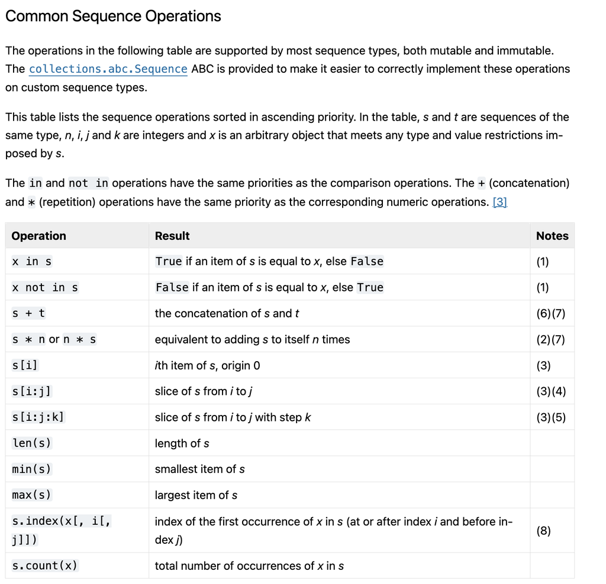

sequence operations

https://docs.python.org/3/library/stdtypes.html#typesseq-common

## Implication

- All built-in sequences (e.g., string, lists, tuple) can utilize the common operations of:
  - membership testing
  - concatenation
  - slicing
  - length
  - and a few others

## Indexing & Slicing rules of (built-in) Sequences

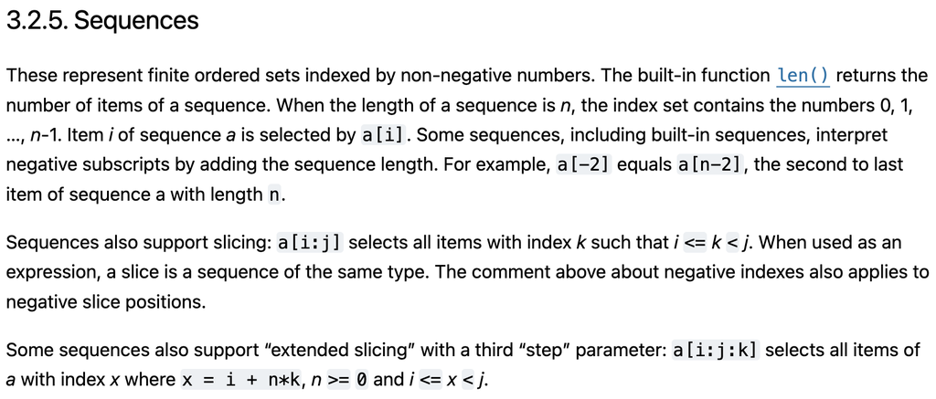

https://docs.python.org/3/reference/datamodel.html#sequences

## Application

- Let’s examine
  - indexing a[i]
  - slicing a[i:j] this is all k such that i <= k < j
  - extended slicing a[i:j:k]
    - (selects all items of a with index x where x = i + n*k, n >= 0 and i <= x < j)
- Why? because indexing & slicing sequences are useful
- Strings, (Ranges), Lists and Tuples - simplest sequences

## Strings are a data type and are sequences

- Strings are sequences of characters and symbols, representing text
- Strings are immutable (more later), does not allow modification after creation.
- Strings are defined using single quotes ’’ or double quotes “”
- The common sequence operations apply to strings

## String Indexing and Slicing Example

```python
text = 'Malayalam' # a language of Kerala

# Indexing
print(text[1])  # Output: 'a' Python is 0 indexed

# Indexing with negation
print(text[-1]) # Output: last letter

# Slicing
print(text[1:4])  # Output: 'ala' (i <= k < j)

# Slicing with steps
print(text[::2])  # Output: 'Mlylm'

# Reversing a string
print(text[::-1])  # Output: 'malayalaM'
```

```
a
m
ala
Mlylm
malayalaM
```

## Additional String Operations

concatenation, repetition, length checking, membership testing, **iteration**

```python
text = 'UCLA'

print(f'Concatenating {text + " #1 Public University"}')
print(f'Yes you can multiply by 3 for repetition: {(text + " ") * 3}')
print(f'According to USC students, {text} is a {len(text)}-letter word')
print(f'Is there a Z in {text}? {"Z" in text}')

for things in text: # all sequences are iterable
    print(things)

print("fight! " * 3)
```

```
Concatenating UCLA #1 Public University
Yes you can multiply by 3 for repetition: UCLA UCLA UCLA
According to USC students, UCLA is a 4-letter word
Is there a Z in UCLA? False
U
C
L
A
fight! fight! fight!
```

## Range: a (lazy) sequence & a data structure

- Immutable sequence of numbers
- Typical use: iterating a specific number of times in loops.
- range() becomes concrete when iterated or simply operated upon

```python
r = range(6) # stop value

print(r)
print(len(r))
print(type(r))

for junk in r:
    print(junk, end = " ")
print()

s = range(1, 100, 2) # start, stop, step
print(s)
print(len(s))
for stuff in s:
    print(stuff, end = " ")
    # it ran off the page use enumerate() to fix
```

```
range(0, 6)
6
<class 'range'>
0 1 2 3 4 5
range(1, 100, 2)
50
1 3 5 7 9 11 13 15 17 19 21 23 25 27 29 31 33 35 37 39 41 43 45 47 49 51 53 55 57 59 61 63 65 67 69 71 73 75 77 79 81 83 85 87 89 91 93 95 97 99
```

### (optional) Aside, getting output to stay in tidy rows

- enumerate(data) returns both an index (i) and its value (stuff).
- Make note of the indentation, this becomes more important next week

```python
N = 10
for i, stuff in enumerate(s, start = 1):
    print(stuff, end = " ") # first print
    if i % N == 0:  # check then at every N numbers
        print()  # print a new line
```

```
1 3 5 7 9 11 13 15 17 19
21 23 25 27 29 31 33 35 37 39
41 43 45 47 49 51 53 55 57 59
61 63 65 67 69 71 73 75 77 79
81 83 85 87 89 91 93 95 97 99
```

### (optional) Character sequences

We could do this for letters like A through Z but let’s try something different.

```python
for i in range(ord('ᚠ'), ord('ᚾ') + 1):
        print(chr(i), end = " ")
```

```
ᚠ ᚡ ᚢ ᚣ ᚤ ᚥ ᚦ ᚧ ᚨ ᚩ ᚪ ᚫ ᚬ ᚭ ᚮ ᚯ ᚰ ᚱ ᚲ ᚳ ᚴ ᚵ ᚶ ᚷ ᚸ ᚹ ᚺ ᚻ ᚼ ᚽ ᚾ
```

ord( ) converts to numeric and chr() converts back to character. We use print to reveal each character.

### (optional for now) Character sequences & list comprehension

We will study this next week. Better that you should see *list comprehension* now because it may need time to be fully understood. Inspired by mathematics, it is Pythonic & here is an example:

```python
characters_comp = [chr(i) for i in range(ord('ᚠ'), ord('ᚾ') + 1)]

print(characters_comp)
```

```
['ᚠ', 'ᚡ', 'ᚢ', 'ᚣ', 'ᚤ', 'ᚥ', 'ᚦ', 'ᚧ', 'ᚨ', 'ᚩ', 'ᚪ', 'ᚫ', 'ᚬ', 'ᚭ', 'ᚮ', 'ᚯ', 'ᚰ', 'ᚱ', 'ᚲ', 'ᚳ', 'ᚴ', 'ᚵ', 'ᚶ', 'ᚷ', 'ᚸ', 'ᚹ', 'ᚺ', 'ᚻ', 'ᚼ', 'ᚽ', 'ᚾ']
```

compare it with:

```python
characters = [] # initialize an empty list
for i in range(ord('ᚠ'), ord('ᚾ') + 1):
    characters.append(chr(i)) # fill it up via append

print(characters)
```

```
['ᚠ', 'ᚡ', 'ᚢ', 'ᚣ', 'ᚤ', 'ᚥ', 'ᚦ', 'ᚧ', 'ᚨ', 'ᚩ', 'ᚪ', 'ᚫ', 'ᚬ', 'ᚭ', 'ᚮ', 'ᚯ', 'ᚰ', 'ᚱ', 'ᚲ', 'ᚳ', 'ᚴ', 'ᚵ', 'ᚶ', 'ᚷ', 'ᚸ', 'ᚹ', 'ᚺ', 'ᚻ', 'ᚼ', 'ᚽ', 'ᚾ']
```

- Compare list comprehension with the previous slide.
- List comprehension *implicitly* constructs a list (here characters_comp) by applying an expression (here chr(i)) to each item in the range (the iterable) while it is iterating within a list [ ].
- Can also use an “if” – [expression for variable in iterable if condition]
- List comprehension creates, iterates, and collects the results all in one line.

## Lists

- Lists are built-in data structures and sequences
- They are subject to the common built-in sequence functions like len(list)
- They also have their own methods e.g. **characters.append(chr(i))** in the previous slide
- List comprehension is a feature of Python syntax that provides a concise way to generate lists.
- But let’s slow it down a little

# Activity 1

## What’s in a name?

- Please gather together in small groups, please make sure at least one member has a laptop
- for credit: minimum group size 3, no max BUT at least one classmate who wasn’t on your previous team
- please introduce yourselves and try to learn a new name today
- please take a group photo, annotate with with names or add names as a comment during upload
- upload a photo individually for attendance credit

## What to do in your group (10-15 minutes)

- You could find out if everyone has Python, can use the Python interpreter (REPL) and a notebook (e.g. Jupyter)
- You could try to answer my questions below and do it all as one or do things separately and then share what you tried. Using any of your tools (e.g. REPL, a Python Script, a Jupyter Notebook or a Quarto Document) Try to create at least one of the following:
  - docstring or comment or f-string
  - try an operation (comparison, simple, or augmented operators)
  - create a sequence(s), slice, concatenate, iterate?
  - create a longer string, or a list, tuple, range
  - try slicing or indexing etc.
- OR try my question on the next slide

## Please explain

Your friend is trying to teach himself Python by watching videos on YouTube. He has a question for you:

He wants the last letter of every spell extracted, when he runs his code, it runs without error, but only an “s” is printed.

```python
spells = [
    "Expelliarmus",
    "Colloshoo",
    "Legilimens",
    "Impedimenta",
    "Confundo",
    "Finite Incantatem",
    "Incarcerous"
]

for spell in spells:
    first = spell[-1]

print(first, end = " ")
```

```
s
```

- You can copy and modify the code to solve his problem
- But please be prepared explain to him why he is only getting an “s”
- Please tell him what he needs to change to get all of the last letters.

## Built-in Data Structures

- These are some ways in “core” Python to store and organize data
- NumPy has arrays and Pandas has DataFrames but those are not “core” Python (third party libraries)
- We have different data structures to suit different needs

| Name | Type | Mutable? | Sequence? | Example |
| --- | --- | --- | --- | --- |
| List | list | yes | yes | [‘Expelliarmus’, ‘Confundo’] |
| Tuple | tuple | no | yes | (0, 2, 4, 6) |
| Dictionary | dict | yes | no (mapping, cannot be indexed but it is iterable) | {‘name’: ‘Bob’, ‘age’: 31, ‘job’: ‘Builder’} |
| Set | set | yes | no (unordered collection, cannot be indexed or sliced but it is iterable) | {‘cherry’, ‘apple’, ‘orange’} |

## But is it a sequence?

```python
from collections.abc import Sequence

print(isinstance([],  Sequence))  # True (list)
print(isinstance((),  Sequence))  # True (tuple)
print(isinstance("",  Sequence))  # True (string)
print(isinstance(range(5),  Sequence))  # True
print(isinstance(set(),  Sequence))  # False
print(isinstance({},  Sequence))  # False (dictionary keys)

print(isinstance(10, Sequence))  # False (integer)
print(isinstance(3.14,  Sequence))  # False (float)
print(isinstance(True, Sequence)) # False (bool)
print(isinstance(None,  Sequence))  # False
```

```
True
True
True
True
False
False
False
False
False
False
```

## But is it iterable?

```python
from collections.abc import Iterable

print(isinstance([], Iterable))  # True (list)
print(isinstance((), Iterable))  # True (tuple)
print(isinstance("", Iterable))  # True (string)
print(isinstance(range(5), Iterable))  # True
print(isinstance(set(), Iterable))  # True
print(isinstance({}, Iterable))  # True (dictionary keys)

print(isinstance(10, Iterable))  # False (integer)
print(isinstance(3.14, Iterable))  # False (float)
print(isinstance(True, Sequence)) # False (bool)
print(isinstance(None, Iterable))  # False
```

```
True
True
True
True
True
True
False
False
False
False
```

## Data Structures: Lists & Tuples

- Lists are:
  - Mutable sequences that allow modification after creation
  - Defined using square brackets []
  - Commas separate items
  - Can contain items of different data types (e.g., text, int, float)
  - Can have duplicate items
  - Relatively high resource use due to mutability so can be slow
  - Use: storing data that is dynamic
- Tuples are:
  - Immutable sequences, their items cannot be changed after creation.
  - For readability, define them using parentheses () – some other ways:
  - Using a trailing comma for a singleton tuple: a, or (a,)
  - Simply separating items with commas: a, b, c or (a, b, c)
- Commas separate each item
- Can contain items of different data types (e.g., text, int, float)
- Can contain duplicate values
- Have lower resource usage than lists
- Use: storing related data that should be unchanging

## The meaning of Mutability & Immutablility

- Strings
- Lists
- List mutability recap
- Tuples
- More Tuples

Strings are immutable, to change a string is a reassignment in memory.

```python
a = 'UCB'  # UC Berkeley
b = 'UCB'  # UC Berkeley
print(f'The value of a is {a} and id = {id(a)} \n')
print(f'The value of b is {b} and id = {id(b)} \n')

a = a + 'C' # concatenation
print(f'The value of a is now {a} and id = {id(a)} \n')
print(f'The value of b is now {b} and id = {id(b)} \n')

a = 'UCBC'
print(f'The value of a is now {a} and id = {id(a)} \n')
print(f'The value of b is now {b} and id = {id(b)} \n')
```

```
The value of a is UCB and id = 4917044848

The value of b is UCB and id = 4917044848

The value of a is now UCBC and id = 4917044656

The value of b is now UCB and id = 4917044848

The value of a is now UCBC and id = 4917045568

The value of b is now UCB and id = 4917044848
```

Lists are mutable data structures, notice the differences

```python
a = ['UCB']
b = a
print(f'The value of a is {a} and id = {id(a)} \n')
print(f'The value of b is {b} and id = {id(b)} \n')

a[0]= 'UCBC'
print(f'The value of a is now {a} and id = {id(a)} \n')
print(f'The value of b is now {b} and id = {id(b)} \n')

a = ['UCBC']
print(f'The value of a is now {a} and id = {id(a)} \n')
print(f'The value of b is now {b} and id = {id(b)} \n')
```

```
The value of a is ['UCB'] and id = 4887195968

The value of b is ['UCB'] and id = 4887195968

The value of a is now ['UCBC'] and id = 4887195968

The value of b is now ['UCBC'] and id = 4887195968

The value of a is now ['UCBC'] and id = 4677140544

The value of b is now ['UCBC'] and id = 4887195968
```

| Action | Operation | a ID | b ID | a Value | b Value |
| --- | --- | --- | --- | --- | --- |
| Assign b = a | Both reference the same list | Same | Same | [‘UCB’] | [‘UCB’] |
| Modify a[0] | List is modified in place | Same | Same | [‘UCBC’] | [‘UCBC’] |
| Reassign a = [‘UCBC’] | a now points to a new list | Changed | Unchanged | [‘UCBC’] (new list) | [‘UCBC’] (old list) |

To avoid the copy of list referencing the same list, there exists a method (more on list methods next time) ‘b = a.copy()’

Tuples are immutable data structures.

```python
a = ('UCB','UCLA')
b = a
print(f'The value of a is {a} and id = {id(a)} \n')
print(f'The value of b is {b} and id = {id(b)} \n')

a[0] = ('UCBC',)
```

```
The value of a is ('UCB', 'UCLA') and id = 4354073984

The value of b is ('UCB', 'UCLA') and id = 4354073984
```

```
---------------------------------------------------------------------------
TypeError                                 Traceback (most recent call last)
Cell In[21], line 6
      3 print(f'The value of a is {a} and id = {id(a)} \n')
      4 print(f'The value of b is {b} and id = {id(b)} \n')
----> 6 a[0] = ('UCBC',)

TypeError: 'tuple' object does not support item assignment
```

Tuples are immutable.

```python
a = ('UCBC','UCLA')
print(f'The value of a is now {a} and id = {id(a)} \n')
print(f'The value of b is now {b} and id = {id(b)} \n')

b = a
a = a + ("UCI",)
print(f'The value of a is now {a} and id = {id(a)} \n')
print(f'The value of b is now {b} and id = {id(b)} \n')
```

```
The value of a is now ('UCBC', 'UCLA') and id = 4923071552

The value of b is now ('UCB', 'UCLA') and id = 4354073984

The value of a is now ('UCBC', 'UCLA', 'UCI') and id = 4923065216

The value of b is now ('UCBC', 'UCLA') and id = 4923071552
```

## Why tuples?

- They are faster during iteration
- They require fewer resources than lists

```python
import time

# Create large list and tuple
large_list = list(range(10**6))
large_tuple = tuple(range(10**6))

# write a little function that sums the sequence
def sum_elements(seq):
    return sum(seq)

# Measure list processing time
start = time.time()
sum_elements(large_list)
end = time.time()
print(f"List sum took: {end - start:.6f} seconds")

# Measure tuple processing time
start = time.time()
sum_elements(large_tuple)
end = time.time()
print(f"Tuple sum took: {end - start:.6f} seconds")
```

```
List sum took: 0.003198 seconds
Tuple sum took: 0.003066 seconds
```

## Sequence common operations recap

Sequences support various operations, including:

- Indexing: Accessing individual elements using their position (starting from 0).
- Slicing: Extracting a subsequence of elements.
- Concatenation: Combining sequences using the + operator.
- Repetition: Repeating a sequence multiple times using the * operator.
- Membership testing: Checking if an element exists in a sequence using the in operator.
- Iteration: Looping through the elements of a sequence using a for loop.
- Length: Determining the number of elements in a sequence using the len() function.

## Optional: Reading a simple text file

```python
# Specify the location of the data

file_path = "gettysburg.txt"  # This is in the same directory as my script - update it with your actual file path

# Open and read the file, first split words using .split()
with open(file_path, "r", encoding="utf-8") as file:
    text = file.read()

    words = text.split()

print(f"Word Count: {len(words)}")

print(f"First 6 words: {words[:6]}")

for word in words[0:6]:
    print(word)

for _ in text[0:6]:
    print(_, end = ' ')
print( )
print([_ for _ in words[0:6]])
```

```
Word Count: 278
First 6 words: ['Four', 'score', 'and', 'seven', 'years', 'ago']
Four
score
and
seven
years
ago
F o u r   s
['Four', 'score', 'and', 'seven', 'years', 'ago']
```

See https://docs.python.org/3/library/stdtypes.html#string-methods for more information and more string methods.

# Part 2: Moving Beyond the Basics

## A riddle

> “What walks on four legs in the morning, two legs at noon, and three legs in the evening?” - The Sphinx
- We are going to start moving towards function writing in Python and from there, Classes + OOP
- If you don’t “get it” right away, please give yourself the grace to think it through.
- Riddles are a mix of logic, language, and lateral thinking (considering alternatives that might not be obvious at first) with fun thrown in (usually anyway, not the Sphinx though).
- Coding Python functions is not too different from solving riddles and puzzles. Coding is more linear for sure but just memorizing known examples is not the same as giving your brain a workout.

## Programming stages

- Variables are things we use to store data
- Iteration operates on items sequentially, standard Python isn’t vectorized like R but libraries like NumPy and Pandas do utilize vectorization
- Control structures (if, while, for) let us decide when to execute statements
- (next week) Functions allow us to express and enclose our problem solving logic and reuse it elsewhere

Like individual ingredients in cooking, the real power of these different stages is revealed when they are combined. The result is greater than the “sum” of its individual parts.

## Coding for Efficiency & Productivity

- It is never too early to start thinking about becoming an efficient and productive Python programmer
  - Have an eye which focuses on breaking down larger tasks into smaller components (task analysis)
  - Use Python to its fullest from standard to popular libraries e.g. NumPy, Pandas
  - Make it a goal to practice writing clear, concise, and well organized code. It will make debugging and collaboration easier and improve productivity as a result
  - Ask yourself (and others) if your code is optimal/efficient
  - Work towards being “Pythonic” in your coding

## Some Examples

- Kaggle is the “home of data science” and a great source for data and discussions about data
- Let’s examine [“Your first machine learning model”](https://www.kaggle.com/code/yogeshtak/exercise-your-first-machine-learning-model) (a Jupyter notebook)
- Let’s examine a more advanced Python script. [Hugging Face speech recognition](https://github.com/huggingface/transformers/blob/main/examples/pytorch/speech-recognition/run_speech_recognition_ctc.py) The “home of machine learning”
- THEY ARE REALLY DIFFERENT! But both are Python.

## Notebooks vs. Scripts

- The Jupter Notebook:
  - Designed for analysis, interactive
  - Written in separate cells, can run them in any order.
  - Typical use: read & manage data, define variables, run models, and get results (DataFest)
  - Python code is minimal, contains lots of markdown, and is straightforward, relatively accessible to a larger audience.
  - Unusual to see custom functions or classes
  - Emphasis is on producing immediate results, not organizing the code for future reuse.
  - Emphasis is on insight/learning/storytelling
- The Professional Script:
  - Multiple functions
  - Multiple classes (indicating OOP)
  - May utilize a GUI
  - Scalable, modular, part of a larger system/library
  - The focus is on building something others can use repeatedly
  - Closer to software engineering/data engineering than analysis

## Where (are you?)/(do you) (want/need) (to be?)

- Data scientists are found between the extremes — initially testing/creating/experimenting in notebooks
- Then converting those notebooks scripts as the model development proceeds
- Whether you analyze data with Python or build a preprocessing pipeline with Python -
- It’s entirely your decision - but I am tasked with teaching material at both ends

# Back to the program

## Default Execution Order in Python

- As designed, Python code works in the following way
  - Top to bottom: Python reads and executes code line by line
  - Left to right (within a code line): Python evaluates expressions from left to right, following operator precedence.
- Restated: in a simple .py script, Python follows a strict “top to bottom, left to right” execution order.
- Top to bottom execution order is NOT followed by notebooks. A notebook looks like it runs top to bottom, BUT it’s on the user to write/run cells in order — Python does not enforce order.
- For both, strict execution order can be changed when we introduce control flow statements (if, for, while, match, etc.) or functions which have the ability to modify the execution order (e.g., exit())

## Modifying Execution Flow

Whether you are programming a script or a notebook, these work in the same manner.

- if True
- if False
- if-elif
- if-elif
- else

```python
print("Step 1: Welcome to club!")  # Executed first

MIN_AGE = 21
age = 19

if age < MIN_AGE:  # Condition is checked
    # print() executed only when the if condition is True
    print(f"Step 2: Sorry you are younger than {MIN_AGE}, you may not enter.")

# Always executed
print("Step 3: The club closes at midnight")
```

```
Step 1: Welcome to club!
Step 2: Sorry you are younger than 21, you may not enter.
Step 3: The club closes at midnight
```

```python
print("Step 1: Welcome to club!")  # Executed first

MIN_AGE = 21
age = 22

if age < MIN_AGE:  # Condition is checked
    # Executed only if condition is True
    print(f"Step 2: sorry you are younger than {MIN_AGE}, you cannot enter")

# This print() is always executed
print("Step 3: The club closes at midnight")
```

```
Step 1: Welcome to club!
Step 3: The club closes at midnight
```

- Python still executes from top to bottom.
- if modifies flow by conditionally skipping or executing a block.
- indented code only runs if the condition is True.

```python
print("Step 1: Welcome to club!")  # Executed first

MIN_AGE = 21
age = 19

if age < MIN_AGE:  # Condition is checked
    print(f"Step 2: Sorry you are younger than {MIN_AGE}, you cannot enter")  # Executed only if condition is True
elif age >= MIN_AGE:
    print(f"Step 2: Please come in!")  # Executed only if this condition is True and the previous was False

print("Step 3: The club closes at midnight")  # Always executed
```

```
Step 1: Welcome to club!
Step 2: Sorry you are younger than 21, you cannot enter
Step 3: The club closes at midnight
```

- Use an elif when you have multiple possible conditions, but only one should execute.
- or when you want to avoid unnecessary condition checking after finding a True case.
- or when the conditions are mutually exclusive (only one can be True).

Same thing, but multiple ages

```python
MIN_AGE = 21
ages = range(17,23)
for a in ages:
    print("Step 1: Welcome to club! May we see some ID?")  # Executed first
    if a < MIN_AGE:  # Condition is checked
        print(f"Step 2: Sorry you are {a} and are under {MIN_AGE}, you cannot enter \n")  # Executed only if condition is True
    elif a >= MIN_AGE:
        print(f"Step 2: You are {MIN_AGE} or over Please come in!\n")  # Executed only if this condition is True and the previous was False

print("The blocks terminate when the indentation returns to that of the initial if (or further left like this line)")
```

```
Step 1: Welcome to club! May we see some ID?
Step 2: Sorry you are 17 and are under 21, you cannot enter

Step 1: Welcome to club! May we see some ID?
Step 2: Sorry you are 18 and are under 21, you cannot enter

Step 1: Welcome to club! May we see some ID?
Step 2: Sorry you are 19 and are under 21, you cannot enter

Step 1: Welcome to club! May we see some ID?
Step 2: Sorry you are 20 and are under 21, you cannot enter

Step 1: Welcome to club! May we see some ID?
Step 2: You are 21 or over Please come in!

Step 1: Welcome to club! May we see some ID?
Step 2: You are 21 or over Please come in!

The blocks terminate when the indentation returns to that of the initial if (or further left like this line)
```

- the statements following the if and elif are placed on separate logical lines
- and indented rightward

Use else as a default case when no conditions are met in the if or elif.

```python
scores = [91, 83, 45, 77, 68, None]

for score in scores:
    if score is None:  # Missing
        print(f"Your score was {score} and your grade is 'I' (Incomplete)\n")
    elif  score >= 90:  # Condition is checked
        print(f"Your score was {score} and your grade is 'A' \n")
    elif score >= 80:
        print(f"Your score was {score} and your grade is 'B' \n")
    elif score >= 70:
        print(f"Your score was {score} and your grade is 'C' \n")
    elif score >= 60:
        print(f"Your score was {score} and your grade is 'D' \n")
    else:
        print(f"Your score was {score} and your grade is 'F' \n")
```

```
Your score was 91 and your grade is 'A'

Your score was 83 and your grade is 'B'

Your score was 45 and your grade is 'F'

Your score was 77 and your grade is 'C'

Your score was 68 and your grade is 'D'

Your score was None and your grade is 'I' (Incomplete)
```

- When the if clause evaluates as true, the statements following the if clause execute, and the entire if statement ends.
- When the if clause evaluates as false, the expressions the elif clauses are evaluated in order starting from the first elif.
- Should the first elif evaluate as true, the statements following it are executed, and the entire if statement ends. If not, the next elif will evaluate.
- If process reaches an else, the statements following the else are executed and then the entire block ends.

## When to employ if, elif, else

- **if** is used for the conditional execution of code and the **if** statement is one of the earliest programming concepts. It is used in decision-making.
- Avoid multiple **if** statements, this is inefficient because Python evaluates all of the statements, even when an earlier **if** is True.
- Instead use **if** with **elif** when multiple conditions exist, but only one of them should execute.
- Use an **else** for a default case when no previous conditions are satisfied.

## match and when to use it

- **match** is a newer control structure designed for pattern matching
- its effect in Python is like **if-elif-else**
- **match** is best for complex condition patterns because its more readable than having a complicated **if-elif-else** with multiple elif

## (optional) match and case (with in)

- match is relatively new to Python (late 2021)
- in Stats 21, **if-elif-else** will cover your needs
- but match is not difficult to understand

```python
scores = [91, 83, 45, 77, 68, None]

for score in scores:
    match score:
        case None:
            grade = "I"  # Incomplete
        # the _ is a wildcard variable that is not kept
        case _ if score in range(90, 101):  # 90-100
            grade = "A"
        case _ if score in range(80, 90):   # 80-89
            grade = "B"
        case _ if score in range(70, 80):   # 70-79
            grade = "C"
        case _ if score in range(60, 70):   # 60-69
            grade = "D"
        case _:
            grade = "F"  # Anything below 60

    print(f"Your score was {score} and your grade is '{grade}'\n")
```

```
Your score was 91 and your grade is 'A'

Your score was 83 and your grade is 'B'

Your score was 45 and your grade is 'F'

Your score was 77 and your grade is 'C'

Your score was 68 and your grade is 'D'

Your score was None and your grade is 'I'
```

## (optional) while

- [Documentation](https://docs.python.org/3/reference/compound_stmts.html#the-while-statement)
- The **while** statement is used for repeated execution as long as an expression is true:
- Nearly everything a **while** can do can be replaced by other statements such as **for**
- But **while** can be used:
  - A **“while True:”** creates a infinite loop because True is always true
  - The code within the loop will continue to execute repeatedly until it encounters a **break** statement or is externally interrupted.
  - It is used when the number of iterations isn’t a known value or when waiting for specific conditions to be met.

## (optional) while example

```python
"""
    script is name_to_a1z26.py

    Example of a while

    After waiting for valid Alpha character input

    Converts a name to A1Z26 cipher (A=1, B=2, ..., Z=26)

"""

def name_to_a1z26(name):
    name = name.upper()  # Convert to uppercase for consistency
    return [ord(char) - 64 for char in name if char.isalpha()]  # Convert letters only

attempts = 3
while attempts > 0:
    name = input("Enter your name (or type 'quit' to exit): ")

    if name.lower() == "quit":
        print("Exiting the script")
        break

    valid = True  # Assume the input is valid

    for char in name:
        if not (char.isalpha() or char in [" ", "-", "'"]):  # Check each character
            valid = False  # Found an invalid character
        break  # Stop checking further

    if valid:
        cleaned_name = name.replace(" ", "").replace("-", "").replace("'", "")  # Remove unwanted chars
        cipher_values = name_to_a1z26(cleaned_name)
        print(f"Your name in A1Z26 cipher: {cipher_values}")
        break  # Exit the loop if a valid name was given

    attempts -= 1
    print(f"Invalid input. {attempts} attempts left.")


if attempts == 0:
    print("Too many invalid attempts. Please come back when you are ready")

if __name__ == "__main__":
    print("name_to_a1z26.py was executed directly") # this is here for teaching only
    name_to_a1z26(name)
```

## Break

- The `break` statement in Python is used to exit a loop early when a specific condition is met.
- The `break` statement used with `for` and `while` loops to stop execution when further iteration is unnecessary.
- In this example, only the last tab will run as intended, the first three highlight the use of break
- Break Part 1
- Break Part 2
- Break Part 3
- Break Example Complete

```python
attempts = 3
while attempts > 0:
    name = input("Enter your name (or type 'quit' to exit): ")

    if name.lower() == "quit": # typing quit means exit immediately
        print("Exiting the script")
        break
```

```python
    valid = True  # Assume the input is valid

    for char in name:
        if not (char.isalpha() or char in [" ", "-", "'"]):  # Check each character
            valid = False  # Found an invalid character
        break  # Stop checking further
```

```python
    if valid:
        cleaned_name = name.replace(" ", "").replace("-", "").replace("'", "")  # Remove unwanted chars
        print(f"Your name as I understand it: {cleaned_name}")
        break  # Exit the loop if a valid name was given

    attempts -= 1
    print(f"Invalid input. {attempts} attempts left.")


if attempts == 0:
    print("Too many invalid attempts. Please come back when you are ready to type")
```

```python
"""
A while, for and break example

break_ex.py (it's just a modified name_to_a1z26.py)

should be run at the prompt like:

python break_ex.py
"""

attempts = 3
while attempts > 0:
    name = input("Enter your name (or type 'quit' to exit): ")

    if name.lower() == "quit": # typing quit means exit immediately
        print("Exiting the script")
        break

    valid = True  # Assume the input is valid

    for char in name:
        if not (char.isalpha() or char in [" ", "-", "'"]):  # Check each character
            valid = False  # Found an invalid character
        break  # Stop checking further

    if valid:
        cleaned_name = name.replace(" ", "").replace("-", "").replace("'", "")  # Remove unwanted chars
        print(f"Your name as I understand it: {cleaned_name}")
        break  # Exit the loop if a valid name was given

    attempts -= 1
    print(f"Invalid input. {attempts} attempts left.")


if attempts == 0:
    print("Too many invalid attempts. Please come back when you are ready to type")
```

## Continue

- The continue statement in Python is used inside loops to skip the current iteration and move to the next one without executing the remaining code in the loop body
- Sometimes restructuring the loop condition is a better choice than a continue (e.g., using if-else instead)
- Consider what is important to you and whether it is explicit or implicit
- EX 1
- EX 2
- Ex 3
- Ex 4
- This example shows how continue operates
- Skips the rest of the current loop iteration and jumps to the next iteration

```python
scores = [85, 42, 75, 30, 90]

for score in scores:
    if score < 70:
        continue
    print(f"Score {score}: Pass")
```

```
Score 85: Pass
Score 75: Pass
Score 90: Pass
```

If someone were reading this quickly, they might miss the implicit skipping of the failing scores.

- A continue could be rewritten as an if-else
- Here, the decision making is explicit

```python
scores = [85, 42, 75, 30, 90]

for score in scores:
    if score >= 70:
        print(f"Score {score}: Pass")
    else:
        print(f"Score {score}: Fail")
```

```
Score 85: Pass
Score 42: Fail
Score 75: Pass
Score 30: Fail
Score 90: Pass
```

- If you didn’t really care about the failing scores a continue would be more efficient.
- Suppose this was for the actuarial examinations, one might only want the names of people with passing scores.

```python
scores = [85, 42, 75, 30, 90]

for score in scores:
    if score < 70:
        continue  # Skip failing scores
    print(f"Score {score}: Pass")
```

```
Score 85: Pass
Score 75: Pass
Score 90: Pass
```

- This optional for week 1, there is yet another data structure called a dictionary.
- We will look at the dictionary again later in the course.
- This is a more realistic version of Ex 3

```python
scores = {
    "Zhiyuan": 85,
    "Yasmin": 42,
    "Xavier": 75,
    "William": 30,
    "Veda": 90
} # scores is a dictionary notice the {} and the :
# these are "key-value" pairs

for name, score in scores.items(): # .items() is a dictionary method works both keys & values
    if score < 50:
        continue  # Skip failing scores
    print(f"{name} passed with a score of {score}.")
```

```
Zhiyuan passed with a score of 85.
Xavier passed with a score of 75.
Veda passed with a score of 90.
```

## Pass

- The pass statement does nothing.
- Here, pass does nothing when num == 2, so all numbers are printed.
- You see it a lot in homework assignments.
- Or when you just need execution to continue as you work on another part of a larger program.

```python
for num in range(5):
    if num == 2:
        pass  # Does nothing, execution continues as usual
    print(num, end = " ")
```

```
0 1 2 3 4
```

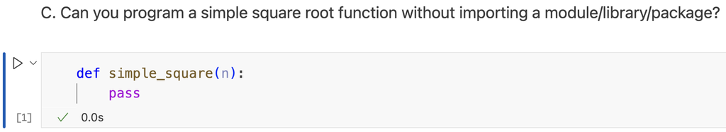

## Difference between Continue and Pass

| Feature | Continue | Pass |
| --- | --- | --- |
| Purpose | Skips the remainder of the current loop iteration and continues to the next iteration | Is a placeholder where a statement is required but pass does nothing |
| Effect on Loop Execution | Moves to the next iteration of the loop | Does nothing; execution moves to the next statement in the block |
| When to use | When skipping specific iterations in a loop | When a block of code is required but no operation needs to be performed |

## Typical Python Script (.py) Structure

- We are moving towards have the ability (or at least an understanding) of how to build a typical Python script.
- We will look all but part five next week
- the fifth part in the week following

| Section | Purpose |
| --- | --- |
| (recommended) Module Docstring | Describes the purpose, help, instructions |
| (depends) Imports | Standard then Third-party then Local libraries |
| Global Constants | Store fixed values (e.g., API URLs file locations) |
| Functions | Define reusable actions |
| (perhaps 50%) Classes | For object-oriented programming |
| (recommended) Main Block (if **name** == ‘**main**’) | Ensures script runs only when executed directly |

# Activity 2

## If we have time

Please try to write Python code that will correctly calculate volume for a sphere with radius 5 and also for radius 15. You might recall the bird age calculations from the previous lecture.

$$V = \frac{4}{3}\pi r^{3}$$

- You will need something to store the volume result V.
- and you will need a way to incorporate the radius (one at a time is easier than using both, I leave it up to you)
- You will need pi, To access pi, **math.pi** will work (pi is found in the math module of the Python Standard Library)
- Your result should display the calculated volume

```python
import math

# some code to calcuate volume
```